# Problem Set 2

ECON329

Colin Pi

## Qustion 1

**(a)**

```r
n <- 43
sample_mean <- 33.1/45
sample_std <- 7.4/45
pop_mean <- 0.78
t_stat <- (sample_mean - pop_mean)/(sample_std/sqrt(n))
p_value1 <- 2*pt(-abs(t_stat),df=n-1)
```

*H*<sub>0</sub>: the averages score equals to 78% ($\mu$ = 0.78)

*H*<sub>1</sub>: the averages score does not equal to 78% ($\mu$ $\neq$ 0.78)

**(b)**

```r
error <- qt(0.995,df=n-2)*0.159
lowerBound <- 0.073 - error
upperBound <- 0.073 + error
```

The 99% confidence interval is -0.356 to 0.502

## Question 2

```r
food <- read.csv("~/Documents/2017-18/ECON329/ps/ps2/FoodExpenditures.csv")
```

**(a)**

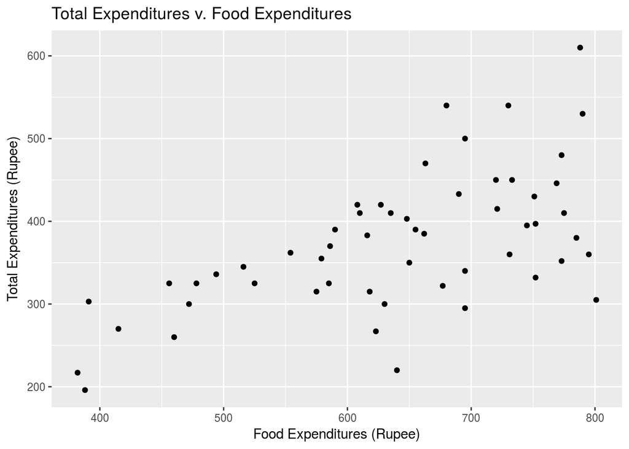

```r
food %>% ggplot(aes(x = TOTALEXP, y=FOODEXP)) +
  geom_point() +
  labs(title="Total Expenditures v. Food Expenditures",x="Food Expenditures (Rupee)",y="Total Expenditures (Rupee)")
```

**(b)**

In that we can observe a non-linear pattern in scatterplot, it violates assumption 1 (linear-in-parameters). Also the model is not likely to follow homoscedasity assumption in that variability of the error gets bigger as x value increases (we can observe a fanning patter in residual plot)

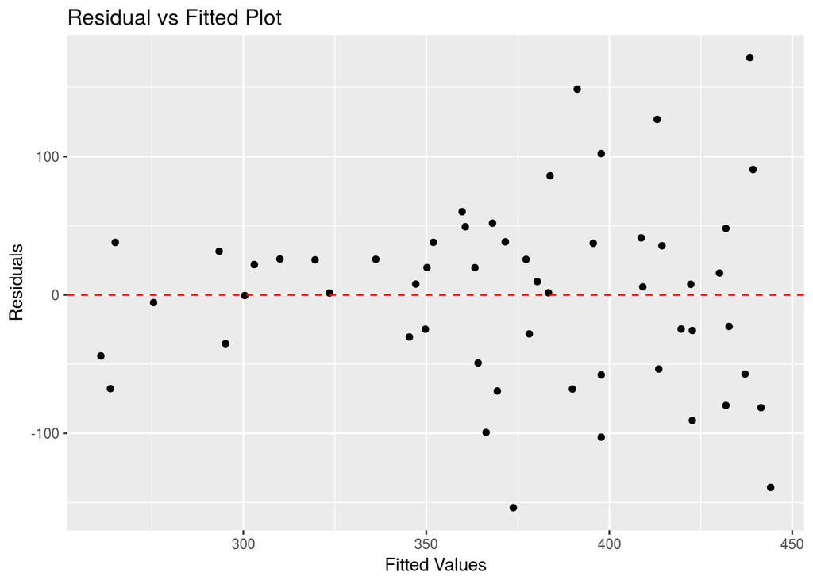

```r
ggplot(lm(FOODEXP~TOTALEXP, data = food)) +
  geom_point(aes(x=.fitted, y=.resid)) +
  geom_hline(yintercept=0, col="red", linetype="dashed") +
  labs(title = "Residual vs Fitted Plot", x="Fitted Values", y = "Residuals")
```

**(c)**

```r
food.lm <- lm(FOODEXP ~ TOTALEXP, data = food)
stargazer(food.lm, type = "html")
```

|  | *Dependent variable:* |
| --- | --- |
|  | FOODEXP |
| TOTALEXP | 0.437*** |
|  | (0.078) |
| Constant | 94.209* |
|  | (50.856) |
| Observations | 55 |
| R<sup>2</sup> | 0.370 |
| Adjusted R<sup>2</sup> | 0.358 |
| Residual Std. Error | 66.856 (df = 53) |
| F Statistic | 31.103*** (df = 1; 53) |
| *Note:* | p<0.1; p<0.05; p<0.01 |

We expect to see 0.437 rupee increase in food expenditure of Indian households for every 1 ruppee increase in their total expenditure (with standard error = 0.078). Also the model says that food expenditure is around 94 rupees when there is no expenditure made by a household (with standard error = 50.856). R<sup>2</sup> value tells us that the about 37% of variability in y is explained by the model.

## Question 3

```r
CountryLevelSheet <- suppressMessages(gs_url("https://docs.google.com/spreadsheets/d/163zuhH_nUXtsDfnnrzuDxJOj4D3Ago1ldEA960JZPmE/"))
CountryLevelData <- suppressMessages(gs_read(CountryLevelSheet))
```

**(a)**

```r
data_2000s <- CountryLevelData %>% filter(year %in% c(2000:2010)) %>% arrange(year)
life_2000s.lm <- lm(lifeExp ~ gdpPercap, data = data_2000s)
stargazer(life_2000s.lm, type = "html")
```

|  | *Dependent variable:* |
| --- | --- |
|  | lifeExp |
| gdpPercap | 0.001*** |
|  | (0.00004) |
| Constant | 58.941*** |
|  | (0.714) |
| Observations | 284 |
| R<sup>2</sup> | 0.461 |
| Adjusted R<sup>2</sup> | 0.459 |
| Residual Std. Error | 8.951 (df = 282) |
| F Statistic | 241.448*** (df = 1; 282) |
| *Note:* | p<0.1; p<0.05; p<0.01 |

```r
association_1 <- round(life_2000s.lm$coefficients[2], digits = 3)
```

We expect to see approximately 0.001 year increase in life expectancy for every $1 increase in GDP per capita (with standard error = 0.00004). We can see that the expected life expectancy of a person is 58.94 years where GDP per capita is 0 (with standard error = 0.714). The R<sup>2</sup> tells us that 46% of the variability of y is explained by the model.

**(b)**

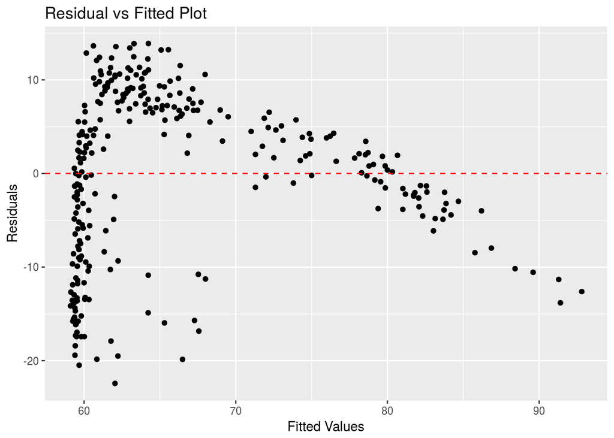

```r
ggplot(lm(lifeExp~gdpPercap, data = data_2000s)) +
  geom_point(aes(x=.fitted, y=.resid)) +
  geom_hline(yintercept=0, col="red", linetype="dashed") +
  labs(title = "Residual vs Fitted Plot", x="Fitted Values", y = "Residuals")
```

Like in the case of Question 2-(a), we can observe non-linear pattern in the scatterplot, so it goes against linear-in-parameters assumption. Also, we can assume that the model without transformation violates homoscedasity assumption as variablity of error may increase as x gets either smaller or bigger (variability of error is smallest when x is in the middle). Moreover, the mean of the residual may not be equal to 0 in any x-value in that residuals are seriously skewed to the right when x<10000 and skewed to the left when x>10000.

## Question 4

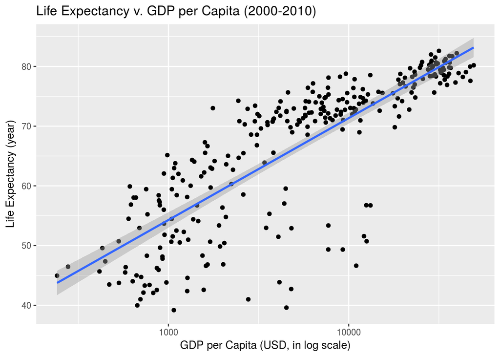

```r
data_2000s %>% ggplot(aes(x = gdpPercap, y = lifeExp)) +
  geom_point() +
  geom_smooth(method = "lm") +
  scale_x_log10() +
  labs(title="Life Expectancy v. GDP per Capita (2000-2010)",x="GDP per Capita (USD, in log scale)",y="Life Expectancy (year)")
```

```r
life_2000s_log.lm <- lm(lifeExp ~ log(gdpPercap), data = data_2000s)
stargazer(life_2000s_log.lm, type = "html")
```

|  | *Dependent variable:* |
| --- | --- |
|  | lifeExp |
| log(gdpPercap) | 7.409*** |
|  | (0.311) |
| Constant | 3.108 |
|  | (2.686) |
| Observations | 284 |
| R<sup>2</sup> | 0.668 |
| Adjusted R<sup>2</sup> | 0.667 |
| Residual Std. Error | 7.023 (df = 282) |
| F Statistic | 568.138*** (df = 1; 282) |
| *Note:* | p<0.1; p<0.05; p<0.01 |

```r
association_2 <- round(life_2000s_log.lm$coefficients[2]*0.01, digits = 3)
```

As the variablity in x is too large relative to that of y, I performed log transformation only on x variable (GDP per capita). The model exhibits that we expect to see approximately 0.074 years increase in life expectancy for every 1% increase in GDP per capita (with standard error = 0.311). The constant value tells us that life expectancy of a person where GDP per capita is 0 is around 3.108 years (with standard error = 2.686, which means statistically insiginificant). The R<sup>2</sup> value shows that about 66.83% percent of the variability in y is explained by the model.

## Challenge Problem

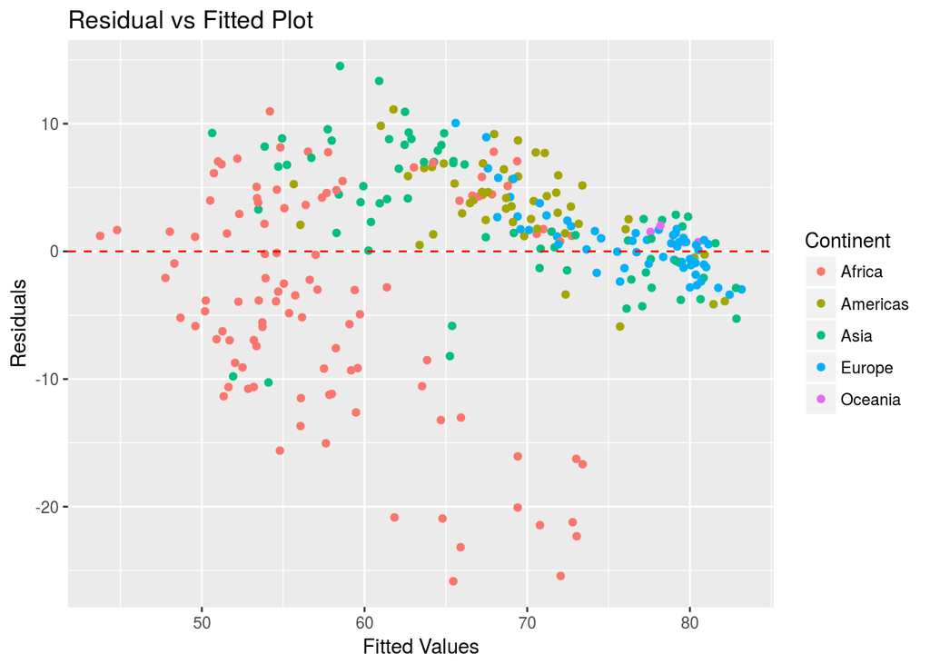

```r
ggplot(lm(lifeExp~log(gdpPercap), data = data_2000s), aes(color = data_2000s$continent))+
  geom_point(aes(x=.fitted, y=.resid)) +
  geom_hline(yintercept=0, col="red", linetype="dashed") +
  labs(title = "Residual vs Fitted Plot", x="Fitted Values", y = "Residuals", color = "Continent")
```

## Question 5

**(a)**

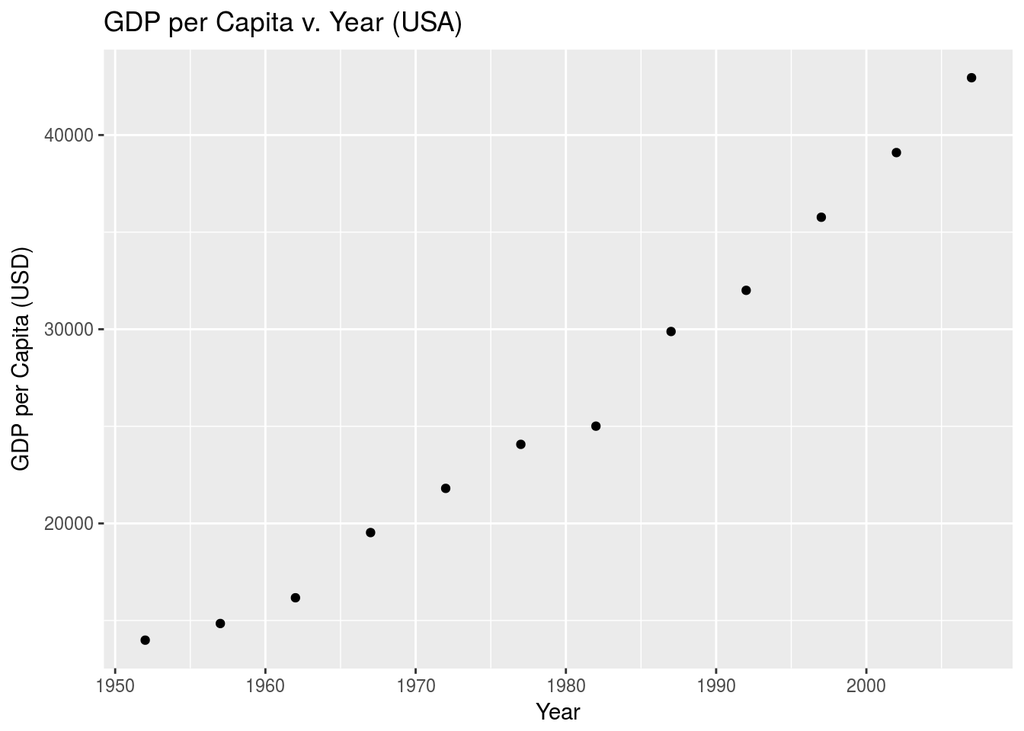

```r
usa <- CountryLevelData %>% filter(country == "United States")
usa %>% ggplot(aes(x = year, y = gdpPercap)) +
  geom_point() +
  labs(title="GDP per Capita v. Year (USA)",x="Year",y="GDP per Capita (USD)")
```

**(b)**

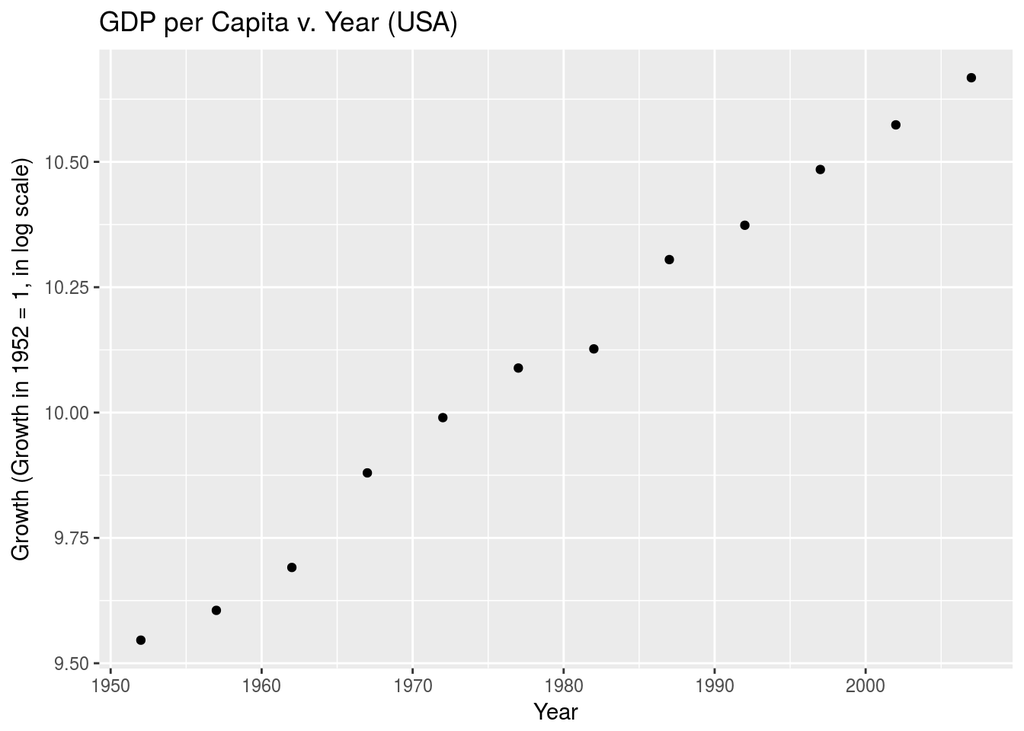

```r
usa %>% ggplot(aes(x = year, y = log(gdpPercap))) +
  geom_point() +
  labs(title="GDP per Capita v. Year (USA)",x="Year",y="Growth (Growth in 1952 = 1, in log scale)")
```

```r
growth.lm <- lm(log(gdpPercap)~year, data = usa)
stargazer(growth.lm, type = "html")
```

|  | *Dependent variable:* |
| --- | --- |
|  | log(gdpPercap) |
| year | 0.021*** |
|  | (0.001) |
| Constant | -31.502*** |
|  | (1.070) |
| Observations | 12 |
| R<sup>2</sup> | 0.993 |
| Adjusted R<sup>2</sup> | 0.993 |
| Residual Std. Error | 0.032 (df = 10) |
| F Statistic | 1,513.093*** (df = 1; 10) |
| *Note:* | p<0.1; p<0.05; p<0.01 |

```r
growth_rate <- exp(growth.lm$coefficients[2])-1
```

log(y<sub>1</sub>) = $\beta$<sub>2</sub>X + $\beta$<sub>1</sub>

log(y<sub>2</sub>) = $\beta$<sub>2</sub>(X+1) + $\beta$<sub>1</sub>

log(y<sub>2</sub>) - log(y<sub>1</sub>) = $\beta$<sub>2</sub>(X+1) + $\beta$<sub>1</sub> - $\beta$<sub>2</sub>X - $\beta$<sub>1</sub>

= $\beta$<sub>2</sub> = log($\frac{y~2~}{y~1~}$)

$\frac{y~2~}{y~1~}$ = e<sup>$\beta$<sub>2</sub></sup>

Therefore, the percentage change of y in every year = (e<sup>$\beta$<sub>2</sub></sup> -1)*100

Growth rate = 0.0212447 $\approx$ 2.12%

**(c)**

```r
interval_2 <- confint(growth.lm)
lowerBound_2 <- exp(interval_2[2,1]) - 1
upperBound_2 <- exp(interval_2[2,2]) - 1
```

The 95% confidence interval is 0.0200157 ($\approx$ 2%) to 0.0224752 ($\approx$ 2.25%)

## Question 6

**(a)**

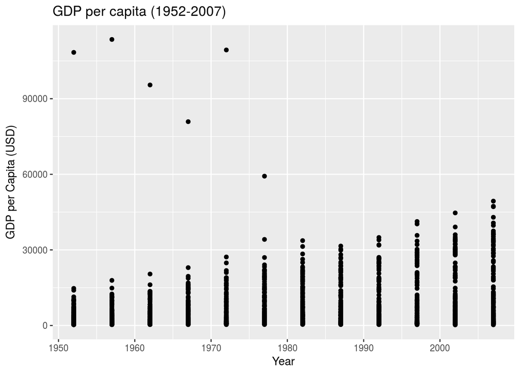

```r
CountryLevelData %>% ggplot(aes(x = year, y = gdpPercap)) +
  geom_point() +
  labs(title="GDP per capita (1952-2007)",x="Year",y="GDP per Capita (USD)")
```

There are six observations that deviate from the general pattern.

```r
CountryLevelData %>% arrange(desc(gdpPercap))
```

```
## # A tibble: 1,704 x 6
##      country continent  year lifeExp     pop gdpPercap
##        <chr>     <chr> <int>   <dbl>   <int>     <dbl>
##  1    Kuwait      Asia  1957  58.033  212846 113523.13
##  2    Kuwait      Asia  1972  67.712  841934 109347.87
##  3    Kuwait      Asia  1952  55.565  160000 108382.35
##  4    Kuwait      Asia  1962  60.470  358266  95458.11
##  5    Kuwait      Asia  1967  64.624  575003  80894.88
##  6    Kuwait      Asia  1977  69.343 1140357  59265.48
##  7    Norway    Europe  2007  80.196 4627926  49357.19
##  8    Kuwait      Asia  2007  77.588 2505559  47306.99
##  9 Singapore      Asia  2007  79.972 4553009  47143.18
## 10    Norway    Europe  2002  79.050 4535591  44683.98
## # ... with 1,694 more rows
```

GDP per capita of Kuwait from 1952 to 1977 are the six outliers. So I decided to remove those points and redrawed the scatterplot.

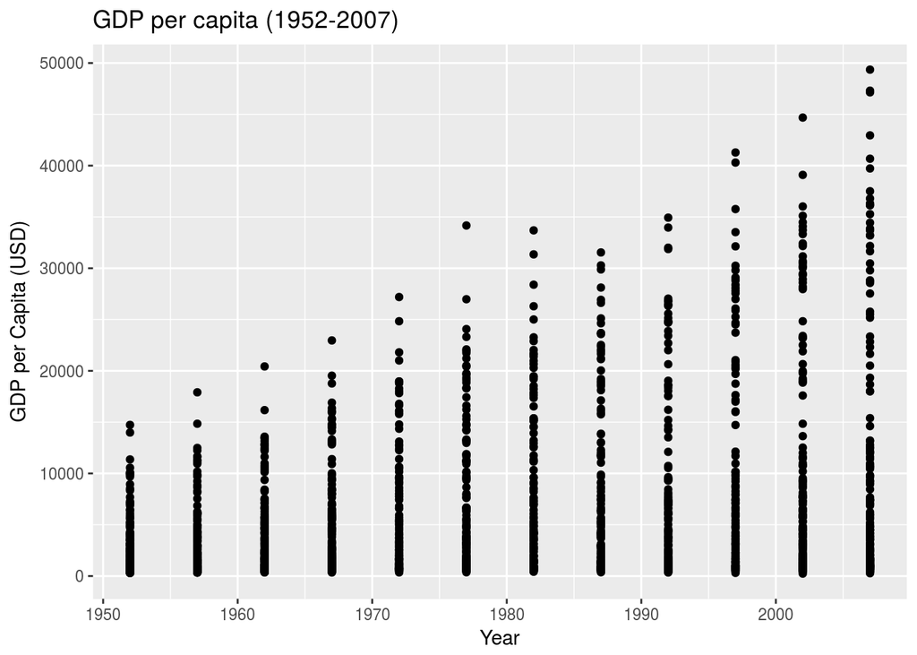

```r
CountryLevelData1 <- CountryLevelData %>% filter(gdpPercap < 59265)

CountryLevelData1 %>% ggplot(aes(x = year, y = gdpPercap)) +
  geom_point() +
  labs(title="GDP per capita (1952-2007)",x="Year",y="GDP per Capita (USD)")
```

Since gdp is exponentially growing as year increases, I decided to log transform gdpPercap.

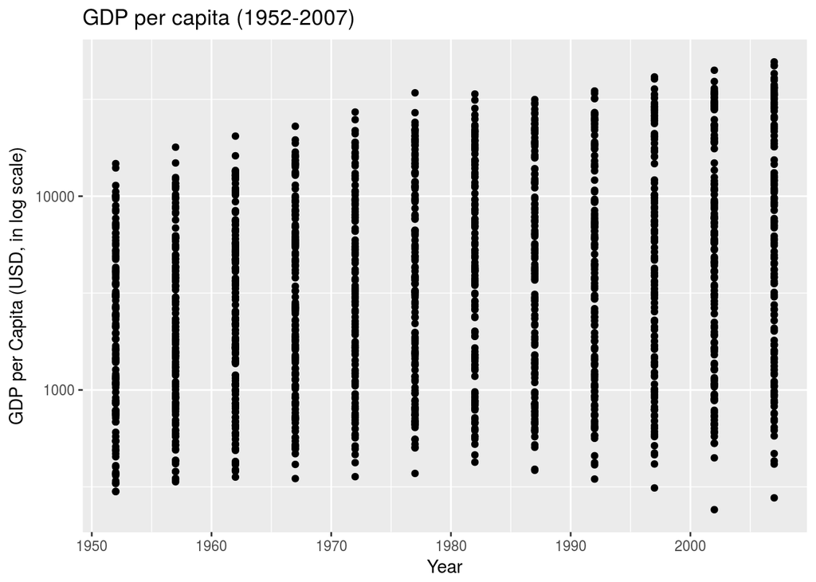

```r
CountryLevelData1 %>% ggplot(aes(x = year, y = gdpPercap)) +
  geom_point() +
  scale_y_log10() +
  labs(title="GDP per capita (1952-2007)",x="Year",y="GDP per Capita (USD, in log scale)")
```

**(b)**

```r
growth.lm2 <- lm(log(gdpPercap)~year, data = CountryLevelData1)
stargazer(growth.lm2, type = "html")
```

|  | *Dependent variable:* |
| --- | --- |
|  | log(gdpPercap) |
| year | 0.017*** |
|  | (0.002) |
| Constant | -26.363*** |
|  | (3.314) |
| Observations | 1,698 |
| R<sup>2</sup> | 0.060 |
| Adjusted R<sup>2</sup> | 0.060 |
| Residual Std. Error | 1.191 (df = 1696) |
| F Statistic | 108.426*** (df = 1; 1696) |
| *Note:* | p<0.1; p<0.05; p<0.01 |

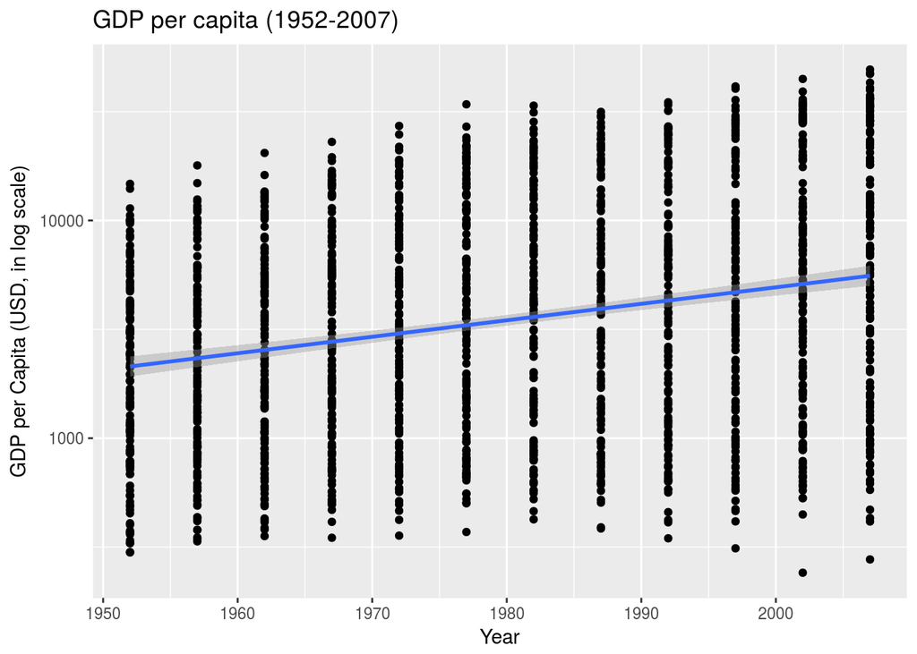

```r
growth_rate_world <- exp(growth.lm2$coefficients[2]) - 1
CountryLevelData1 %>% ggplot(aes(x = year, y = gdpPercap)) +
  geom_point() +
  geom_smooth(method = "lm") +
  scale_y_log10() +
  labs(title="GDP per capita (1952-2007)",x="Year",y="GDP per Capita (USD, in log scale)")
```

Growth rate estimate = 0.0175864 $\approx$ 1.76%

**(c)**

```r
interval_3 <- confint(growth.lm2)
lowerBound_3 <- exp(interval_3[2,1]) - 1
upperBound_3 <- exp(interval_3[2,2]) - 1
```

The 95% confidence interval is 0.0142503 ($\approx$ 1.43%) to 0.0209334 ($\approx$ 2.09%)